# r01_gq_filtering_icr1000_or

Started: David Gilfoyle 15 May 2018  
Updated: David Gilfoyle 16 May 2018

# Summary

GQ Filtering Phred < 20  
Dataset: ICR1000 Gene Selection: Olfactory Receptor Genes  
Input Variants: 5,189

# start_section

```r
Sys.time()
```

```
## [1] "2018-05-16 15:43:33 UTC"
```

```r
rm(list=ls())
graphics.off()

# Make sure all the libraries installed
#install.packages("vcfR")

# Install libraries
library(dplyr)
library(knitr)

# Setup input folder
input_folder="/home/ec2-user/results/filtered/qual_filt/icr1000"
```

# load_rdata_file

```r
# Load RData file - contains dataframe containing all variants
load(paste(input_folder, "r01_icr1000_or_qual_filt.RData", sep="/"))

# Check input fixed column dataframe
dim(fixed_qfilt_icr1000_or.df)
```

```
## [1] 5189   92
```

```r
class(fixed_qfilt_icr1000_or.df)
```

```
## [1] "data.frame"
```

```r
fixed_qfilt_icr1000_or.df[1:20,1:10]
```

```
##                CHROM    POS          ID REF ALT     QUAL FILTER ABHet
## rs201219564_4      1  69270 rs201219564   A   G 32265.00   <NA> 0.508
## 1_69453_7          1  69453        <NA>   G   A  8028.81   <NA> 0.667
## rs75062661_9       1  69511  rs75062661   A   G 16617.40   <NA>    NA
## rs75062661_10      1  69511  rs75062661   A   T 16617.40   <NA>    NA
## rs55874132_11      1  69552  rs55874132   G   C  1248.10   <NA> 0.825
## rs372127752_12     1  69569 rs372127752   T   C  2682.41   <NA> 0.771
## 1_69751_14         1  69751        <NA>   C   T   769.35   <NA> 0.867
## rs200505207_15     1  69761 rs200505207   A   T 16581.30   <NA> 0.627
## 1_69849_16         1  69849        <NA>   G   A   452.10   <NA> 0.843
## 1_69869_17         1  69869        <NA>   T   A   339.65   <NA> 0.746
## rs200676709_18     1  69897 rs200676709   T   C 57811.60   <NA> 0.749
## 1_69932_20         1  69932        <NA>   C   T  2132.04   <NA> 0.806
## 1_69996_23         1  69996        <NA>   T   C   352.23   <NA> 0.782
## 1_621358_26        1 621358        <NA>   C   A   603.10   <NA> 0.785
## 1_621465_31        1 621465        <NA>   G   A  1150.62   <NA>    NA
## 1_621465_32        1 621465        <NA>   G   T  1150.62   <NA>    NA
## 1_621536_36        1 621536        <NA>   C   G   841.43   <NA> 0.770
## 1_621646_39        1 621646        <NA>   A   C  5126.91   <NA> 0.837
## 1_621716_40        1 621716        <NA>   C   T   505.37   <NA> 0.841
## 1_621770_41        1 621770        <NA>   G   A   984.11   <NA>    NA
##                ABHom  AC
## rs201219564_4  0.928 825
## 1_69453_7      0.826 408
## rs75062661_9      NA 659
## rs75062661_10     NA  24
## rs55874132_11  0.949 134
## rs372127752_12 0.937 220
## 1_69751_14     0.964  80
## rs200505207_15 0.984 130
## 1_69849_16     0.992  25
## 1_69869_17     0.995   4
## rs200676709_18 0.985 554
## 1_69932_20     0.994  54
## 1_69996_23     0.991  10
## 1_621358_26    0.985  22
## 1_621465_31       NA  45
## 1_621465_32       NA  23
## 1_621536_36    0.918  67
## 1_621646_39    0.992 157
## 1_621716_40    0.950 100
## 1_621770_41       NA  20
```

```r
# Check input genotype matrix
dim(gt_qfilt_icr1000_or.mx)
```

```
## [1] 5189  999
```

```r
class(gt_qfilt_icr1000_or.mx)
```

```
## [1] "matrix"
```

```r
gt_qfilt_icr1000_or.mx[1:5,1:5]
```

```
##               EGAR00001237542_1520_A02 EGAR00001237543_1520_A03
## rs201219564_4 NA                       NA
## 1_69453_7     "1/1"                    NA
## rs75062661_9  "1/1"                    NA
## rs75062661_10 "0/0"                    NA
## rs55874132_11 "0/0"                    NA
##               EGAR00001237544_1520_A04 EGAR00001237545_1520_A08
## rs201219564_4 NA                       NA
## 1_69453_7     NA                       "0/0"
## rs75062661_9  "1/1"                    "1/1"
## rs75062661_10 "0/0"                    "0/0"
## rs55874132_11 "1/1"                    "0/0"
##               EGAR00001237546_1520_A09
## rs201219564_4 NA
## 1_69453_7     NA
## rs75062661_9  NA
## rs75062661_10 NA
## rs55874132_11 NA
```

```r
# Check input GQ matrix
dim(gq_qfilt_icr1000_or.mx)
```

```
## [1] 5189  999
```

```r
class(gq_qfilt_icr1000_or.mx)
```

```
## [1] "matrix"
```

```r
gq_qfilt_icr1000_or.mx[1:5,1:5]
```

```
##               EGAR00001237542_1520_A02 EGAR00001237543_1520_A03
## rs201219564_4                       NA                       NA
## 1_69453_7                            6                       NA
## rs75062661_9                         3                       NA
## rs75062661_10                        3                       NA
## rs55874132_11                        9                       NA
##               EGAR00001237544_1520_A04 EGAR00001237545_1520_A08
## rs201219564_4                       NA                       NA
## 1_69453_7                           NA                        3
## rs75062661_9                         3                        6
## rs75062661_10                        3                        6
## rs55874132_11                        3                       21
##               EGAR00001237546_1520_A09
## rs201219564_4                       NA
## 1_69453_7                           NA
## rs75062661_9                        NA
## rs75062661_10                       NA
## rs55874132_11                       NA
```

```r
# Setup base and output folders
base_folder="/home/ec2-user/scripts/filtration/gq_filt/icr1000"
output_folder="/home/ec2-user/results/filtered/gq_filt/icr1000"

getwd()
```

```
## [1] "/home/ec2-user/scripts/filtration/gq_filt/icr1000"
```

```r
setwd(base_folder)
getwd()
```

```
## [1] "/home/ec2-user/scripts/filtration/gq_filt/icr1000"
```

```r
opts_knit$set(root.dir = base_folder)
```

# gq_filtering

```r
# Check input
gt_qfilt_icr1000_or.mx[1:10,1:4]
```

```
##                EGAR00001237542_1520_A02 EGAR00001237543_1520_A03
## rs201219564_4  NA                       NA
## 1_69453_7      "1/1"                    NA
## rs75062661_9   "1/1"                    NA
## rs75062661_10  "0/0"                    NA
## rs55874132_11  "0/0"                    NA
## rs372127752_12 "0/0"                    NA
## 1_69751_14     NA                       "0/1"
## rs200505207_15 "0/0"                    "0/0"
## 1_69849_16     "0/0"                    "0/0"
## 1_69869_17     "0/0"                    "0/0"
##                EGAR00001237544_1520_A04 EGAR00001237545_1520_A08
## rs201219564_4  NA                       NA
## 1_69453_7      NA                       "0/0"
## rs75062661_9   "1/1"                    "1/1"
## rs75062661_10  "0/0"                    "0/0"
## rs55874132_11  "1/1"                    "0/0"
## rs372127752_12 "1/1"                    "0/0"
## 1_69751_14     "0/0"                    "0/0"
## rs200505207_15 "0/0"                    "0/0"
## 1_69849_16     "0/0"                    "0/0"
## 1_69869_17     "0/0"                    "0/0"
```

```r
gq_qfilt_icr1000_or.mx[1:10,1:4]
```

```
##                EGAR00001237542_1520_A02 EGAR00001237543_1520_A03
## rs201219564_4                        NA                       NA
## 1_69453_7                             6                       NA
## rs75062661_9                          3                       NA
## rs75062661_10                         3                       NA
## rs55874132_11                         9                       NA
## rs372127752_12                       12                       NA
## 1_69751_14                           NA                       16
## rs200505207_15                       12                        6
## 1_69849_16                           15                       12
## 1_69869_17                           24                       24
##                EGAR00001237544_1520_A04 EGAR00001237545_1520_A08
## rs201219564_4                        NA                       NA
## 1_69453_7                            NA                        3
## rs75062661_9                          3                        6
## rs75062661_10                         3                        6
## rs55874132_11                         3                       21
## rs372127752_12                        3                       21
## 1_69751_14                            6                       15
## rs200505207_15                        3                       12
## 1_69849_16                           18                       15
## 1_69869_17                           27                       33
```

```r
# Filter GT (placing NA in appropriate cells) when GQ > 20
NA -> gt_qfilt_icr1000_or.mx[ gq_qfilt_icr1000_or.mx < 20 ]

# Check output
gt_qfilt_icr1000_or.mx[1:10,1:4]
```

```
##                EGAR00001237542_1520_A02 EGAR00001237543_1520_A03
## rs201219564_4  NA                       NA
## 1_69453_7      NA                       NA
## rs75062661_9   NA                       NA
## rs75062661_10  NA                       NA
## rs55874132_11  NA                       NA
## rs372127752_12 NA                       NA
## 1_69751_14     NA                       NA
## rs200505207_15 NA                       NA
## 1_69849_16     NA                       NA
## 1_69869_17     "0/0"                    "0/0"
##                EGAR00001237544_1520_A04 EGAR00001237545_1520_A08
## rs201219564_4  NA                       NA
## 1_69453_7      NA                       NA
## rs75062661_9   NA                       NA
## rs75062661_10  NA                       NA
## rs55874132_11  NA                       "0/0"
## rs372127752_12 NA                       "0/0"
## 1_69751_14     NA                       NA
## rs200505207_15 NA                       NA
## 1_69849_16     NA                       NA
## 1_69869_17     "0/0"                    "0/0"
```

```r
gq_qfilt_icr1000_or.mx[1:10,1:4]
```

```
##                EGAR00001237542_1520_A02 EGAR00001237543_1520_A03
## rs201219564_4                        NA                       NA
## 1_69453_7                             6                       NA
## rs75062661_9                          3                       NA
## rs75062661_10                         3                       NA
## rs55874132_11                         9                       NA
## rs372127752_12                       12                       NA
## 1_69751_14                           NA                       16
## rs200505207_15                       12                        6
## 1_69849_16                           15                       12
## 1_69869_17                           24                       24
##                EGAR00001237544_1520_A04 EGAR00001237545_1520_A08
## rs201219564_4                        NA                       NA
## 1_69453_7                            NA                        3
## rs75062661_9                          3                        6
## rs75062661_10                         3                        6
## rs55874132_11                         3                       21
## rs372127752_12                        3                       21
## 1_69751_14                            6                       15
## rs200505207_15                        3                       12
## 1_69849_16                           18                       15
## 1_69869_17                           27                       33
```

```r
# Clean up
rm(gq_qfilt_icr1000_or.mx)
```

# recode_gt_to_additive

Genotypes which remain following filtering are presented as 0/0, 0/1, 1/1 etc. This section sets up an empty matrix of equivalent dimensions to the genotype matrix, then evaulates each genotype and calculates additive genotype values (0, 1 or 2)

```r
# Set up empty matrix with 'NA' in cells, add row and column names from genotype matrix
gt_add_qfilt_icr1000_or.mx <- matrix(NA,
                                           ncol=ncol(gt_qfilt_icr1000_or.mx),
                                           nrow=nrow(gt_qfilt_icr1000_or.mx))
colnames(gt_add_qfilt_icr1000_or.mx) <- colnames(gt_qfilt_icr1000_or.mx)
rownames(gt_add_qfilt_icr1000_or.mx) <- rownames(gt_qfilt_icr1000_or.mx)

# Check genotype additive matrix
gt_add_qfilt_icr1000_or.mx[65:70,1:4]
```

```
##                EGAR00001237542_1520_A02 EGAR00001237543_1520_A03
## rs141031469_89                       NA                       NA
## 1_158436142_90                       NA                       NA
## rs373234585_91                       NA                       NA
## 1_158436255_92                       NA                       NA
## rs4657080_93                         NA                       NA
## 1_158436354_94                       NA                       NA
##                EGAR00001237544_1520_A04 EGAR00001237545_1520_A08
## rs141031469_89                       NA                       NA
## 1_158436142_90                       NA                       NA
## rs373234585_91                       NA                       NA
## 1_158436255_92                       NA                       NA
## rs4657080_93                         NA                       NA
## 1_158436354_94                       NA                       NA
```

```r
# Check genotype coding present in original genotype matrix
table(gt_qfilt_icr1000_or.mx) # 0/0, 0/1, 1/0 and 1/1 all present
```

```
## gt_qfilt_icr1000_or.mx
##     0/0     0/1     1/0     1/1
## 3613430  598685     815  237137
```

```r
summary(as.factor(gt_qfilt_icr1000_or.mx)) # as.factor allows assessment on NA values present
```

```
##     0/0     0/1     1/0     1/1    NA's
## 3613430  598685     815  237137  733744
```

```r
# Replace genotypes in original genotype matrix with additive values into the additive genotype matrix
0 -> gt_add_qfilt_icr1000_or.mx[ gt_qfilt_icr1000_or.mx == "0/0" ]
1 -> gt_add_qfilt_icr1000_or.mx[ gt_qfilt_icr1000_or.mx == "0/1" ]
1 -> gt_add_qfilt_icr1000_or.mx[ gt_qfilt_icr1000_or.mx == "1/0" ]
2 -> gt_add_qfilt_icr1000_or.mx[ gt_qfilt_icr1000_or.mx == "1/1" ]

# Check updated additive genotype matrix
gt_add_qfilt_icr1000_or.mx[65:70,1:4]
```

```
##                EGAR00001237542_1520_A02 EGAR00001237543_1520_A03
## rs141031469_89                        0                        0
## 1_158436142_90                        0                        0
## rs373234585_91                        0                        0
## 1_158436255_92                        0                        0
## rs4657080_93                          1                        1
## 1_158436354_94                        1                        1
##                EGAR00001237544_1520_A04 EGAR00001237545_1520_A08
## rs141031469_89                        0                        0
## 1_158436142_90                        0                        0
## rs373234585_91                        0                        0
## 1_158436255_92                        0                        0
## rs4657080_93                          0                        1
## 1_158436354_94                       NA                        1
```

```r
# Clean up
rm(gt_qfilt_icr1000_or.mx)
```

# filter_by_call_rate

Following GQ filtering, genotypes associated with variants may not have a high call rate (number of times a genotype is called relative to the number of subjects). Variants with call rates < 0.8 will be filtered out as they are not considered reliable calls

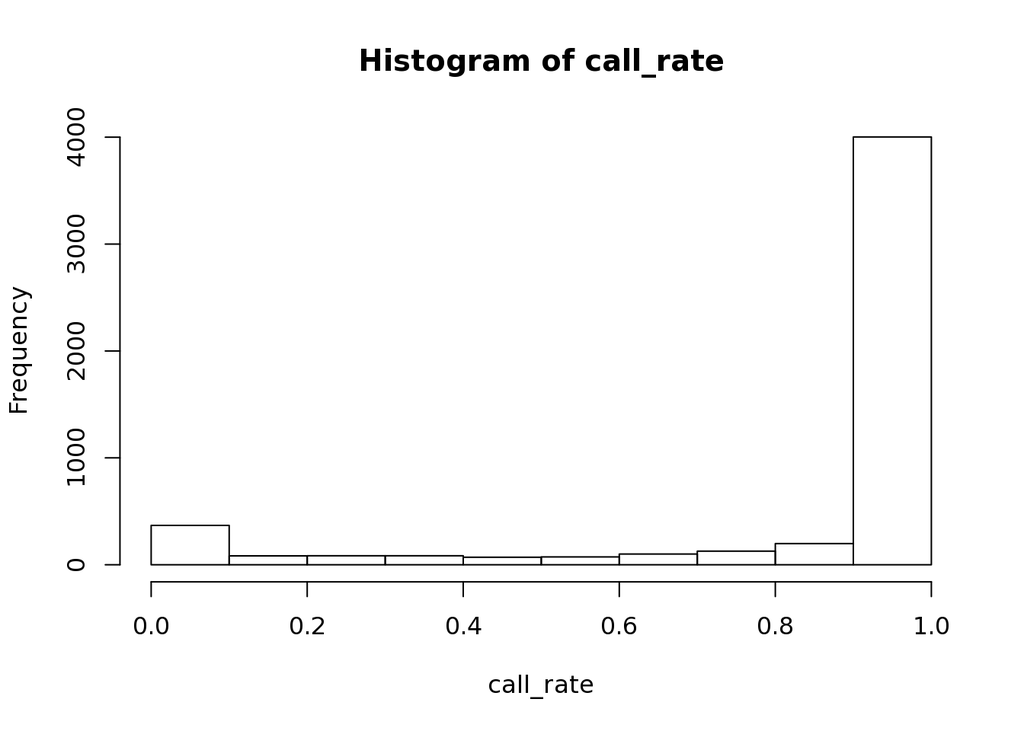

```r
# Set up call rate user defined function
call_rate.udf <- function(vector_of_genotypes){
  result <- sum(!is.na(vector_of_genotypes)) / length(vector_of_genotypes)
  return(result)
}

# Calculate the number of genotype calls for each variant and plot a histogram
call_rate <- apply(gt_add_qfilt_icr1000_or.mx, 1, call_rate.udf)
hist(call_rate, xlim=c(0,1))
```

```r
# Filter call rate >= 0.8
call_rate_pass <- call_rate >= 0.8
sum(call_rate_pass)
```

```
## [1] 4200
```

```r
# Create an additive call rate filtered genotype matrix
gt_add_crfilt_icr1000_or.mx <- gt_add_qfilt_icr1000_or.mx[call_rate_pass,]

# Syncronise fixed column dataframe with variants remaining call rate filtered additive genotype matrix
fixed_crfilt_icr1000_or.df <- fixed_qfilt_icr1000_or.df[call_rate_pass,]

# Check output matricies
dim(gt_add_crfilt_icr1000_or.mx)
```

```
## [1] 4200  999
```

```r
dim(fixed_crfilt_icr1000_or.df)
```

```
## [1] 4200   92
```

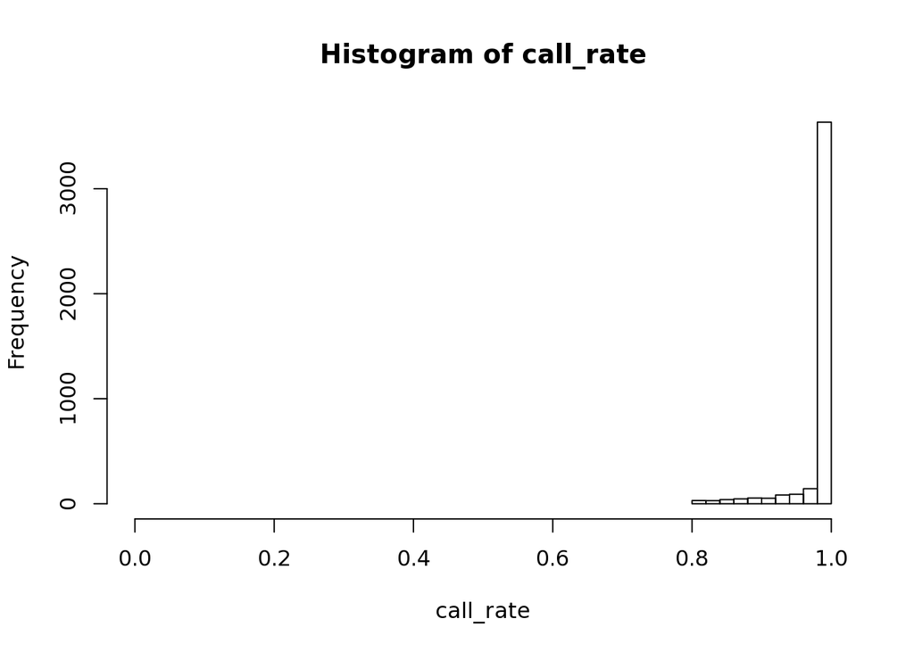

```r
# Calculate the number of genotype calls in the output matrix for each variant and plot a histogram
call_rate <- apply(gt_add_crfilt_icr1000_or.mx, 1, call_rate.udf)
hist(call_rate, xlim=c(0,1))
```

```r
# Clean up
rm(gt_add_qfilt_icr1000_or.mx, fixed_qfilt_icr1000_or.df, call_rate.udf, call_rate, call_rate_pass)
```

# recalculate_af

Following GQ filtering step the AC (allele count; counts for each alternate allele [het = 1; hom = 2 etc.] by variant) and AN (allele number; total number of diploid allele counts across population) are recalculated. This allows the AF (allele frequency; AC divided by AN) to be calculated. The fixed column dataframe is then updated with this information to allow subsequent AF filtering to occur based on updated (new_AF) values

```r
# Calculate updated AC
new_AC <- apply(gt_add_crfilt_icr1000_or.mx, 1, sum, na.rm=T)
new_AC[1:5]
```

```
##     1_69849_16     1_69869_17 rs200676709_18     1_69932_20     1_69996_23
##             15              2            508             41              6
```

```r
# Set up allele number user defined function
get_AN.udf <- function(vector_of_additive_genotypes){
  result <- 2*sum(!is.na(vector_of_additive_genotypes))
  return(result)
}

# Calculate updated AN
new_AN <- apply(gt_add_crfilt_icr1000_or.mx, 1, get_AN.udf)

# Check updated AN values, plot histogram and ensure no variants have AN = 0
new_AN[1:5]
```

```
##     1_69849_16     1_69869_17 rs200676709_18     1_69932_20     1_69996_23
##           1702           1864           1802           1846           1608
```

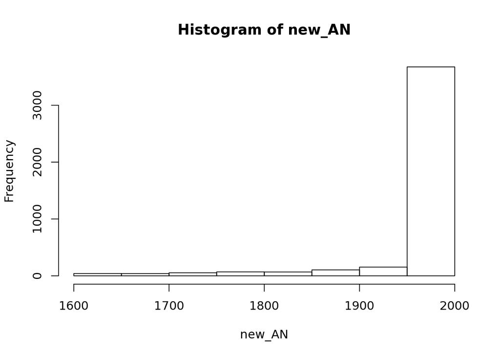

```r
hist(new_AN)
```

```r
sum(new_AN==0)
```

```
## [1] 0
```

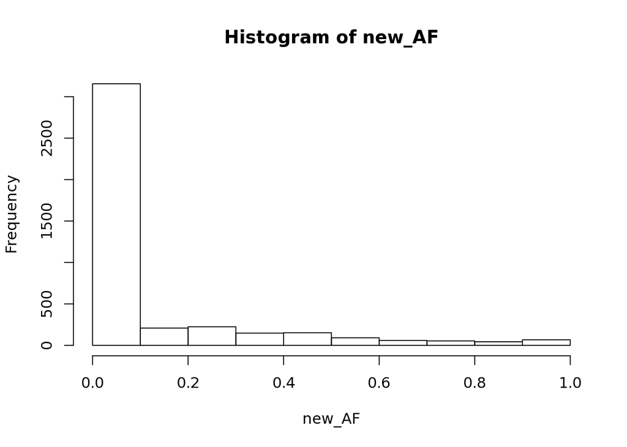

```r
# Calculate updated AF values and plot a histogram
new_AF <- new_AC / new_AN
hist(new_AF)
```

```r
# Introduce updated AC, AN and AF values into fixed column dataframe
fixed_crfilt_icr1000_or.df <- cbind(fixed_crfilt_icr1000_or.df, new_AC, new_AN, new_AF)

# Clean up
rm(get_AN.udf, new_AC, new_AN, new_AF)
```

# save_results

```r
save.image(paste(output_folder, "r01_icr1000_or_gq_filt.RData", sep="/"))
```

# final_section

```r
ls()
```

```
## [1] "base_folder"                 "fixed_crfilt_icr1000_or.df"
## [3] "gt_add_crfilt_icr1000_or.mx" "input_folder"
## [5] "meta.df"                     "output_folder"
```

```r
Sys.time()
```

```
## [1] "2018-05-16 15:44:13 UTC"
```